# CST4070 NLP Challenge

## Introduction

This report presents an analysis of Airbnb reviews, focusing on comparing word usage between the earliest and most recent years in the dataset. The primary objective is to identify trends in how guests describe their experiences over time.

## Data Loading

```r
airbnb_data <- read.csv('reviews.csv')


sum(is.na(airbnb_data$id))
```

```
[1] 0
```

```r
airbnb_data
```

| listing_id | id | date | reviewer_id | reviewer_name | comments |
| --- | --- | --- | --- | --- | --- |
| 13913 | 8.077000e+04 | 2010-08-18 | 177109 | Michael | My girlfriend and I hadn't known Alina before we took the leap of faith to rent her flat. Alina just couldn't be nicer! Her flat is comfortable, homey, very sunny, and quiet at night. Her diverse neig… |
| 13913 | 3.675680e+05 | 2011-07-11 | 19835707 | Mathias | Alina was a really good host. The flat is clean and tidy - and really close to Finsbury Park station which is quite close to Central London. I recommend Alina to everyone. |
| 13913 | 5.295790e+05 | 2011-09-13 | 1110304 | Kristin | Alina is an amazing host. She made me feel right at home. It was more like hanging out with a friend than a complete stranger. She's very sweet and makes a mean espresso. There are tons of places righ… |
| 13913 | 5.954810e+05 | 2011-10-03 | 1216358 | Camilla | Alina's place is so nice, the room is big and clean, and the bed is huge. Alina is a great host, and she made sure I had everything I needed, for instance she had put clean towels on the bed for me:) … |
| 13913 | 6.129470e+05 | 2011-10-09 | 490840 | Jorik | Nice location in Islington area, good for short business trip. House is OK, host is very friendly. |
| 13913 | 4.847959e+06 | 2013-05-28 | 6405442 | Vera | I'm very happy to have been Alina's guest! We've had great time in London and enjoyed our stay. Alina is a great host, we felt us so welcomed by her! \nAlina's house location is very convenient, it's … |
| 13913 | 8.142329e+06 | 2013-10-17 | 9195551 | Honi | I stayed with Alina in her flat in London for a week. It's a wonderful home with a warm feeling and everything you need. Alina went out of her way to make sure I was comfortable and we shared some gre… |
| 13913 | 1.187659e+07 | 2014-04-17 | 5194009 | Alessandro | Alina was a perfect guest and her flat is absolutely wonderful. Highly recommended. \n |
| 13913 | 4.666957e+07 | 2015-09-12 | 42970248 | Oleh | Alina's flat is exceptional one. \nI have to say i have never been to such an atmospheric place like her flat.\nPlenty of stunning art items around and all of these pictures and drawings are magnifice… |
| 13913 | 6.455903e+07 | 2016-03-05 | 45337884 | Mo | The House is a piece of Art , there are beautiful portraits everywhere , so close to the tube station , on piccaddily and Victoria lines , the host alina is very friendly , welcoming , and polite pers… |

[output cut: 990 more lines]

```r
NA
NA
NA
NA
```

## Handling Missing Values and Data Cleaning

- Checking for missing values in the dataset.
- Dropping rows with missing `comments`.
- Displaying the data structure after cleaning.

```r
# Seeing missing values
colSums(is.na(airbnb_data))
```

```
   listing_id            id          date   reviewer_id
            0             0             0             0
reviewer_name      comments
            0            39
```

```r
# drop rows with missing values
reviews_data <- airbnb_data |>
   drop_na(comments)

colSums(is.na(reviews_data))
```

```
   listing_id            id          date   reviewer_id
            0             0             0             0
reviewer_name      comments
            0             0
```

```r
str(reviews_data)
```

```
'data.frame':   1887480 obs. of  6 variables:
 $ listing_id   : num  13913 13913 13913 13913 13913 ...
 $ id           : num  80770 367568 529579 595481 612947 ...
 $ date         : chr  "2010-08-18" "2011-07-11" "2011-09-13" "2011-10-03" ...
 $ reviewer_id  : int  177109 19835707 1110304 1216358 490840 6405442 9195551 5194009 42970248 45337884 ...
 $ reviewer_name: chr  "Michael" "Mathias" "Kristin" "Camilla" ...
 $ comments     : chr  "My girlfriend and I hadn't known Alina before we took the leap of faith to rent her flat. Alina just couldn't b"| __truncated__ "Alina was a really good host. The flat is clean and tidy - and really close to Finsbury Park station which is q"| __truncated__ "Alina is an amazin…
```

## Checking for Duplicates

- Count of the number of duplicate entries in the dataset.

```r
# count of duplicated data
sum(duplicated(reviews_data))
```

```
[1] 0
```

```r
names(reviews_data)
```

```
[1] "listing_id"    "id"            "date"          "reviewer_id"
[5] "reviewer_name" "comments"
```

```r
dim(reviews_data)
```

```
[1] 1887480       6
```

```r
head(reviews_data)
```

|  | listing_id | id | date | reviewer_id | reviewer_name | comments |
| --- | --- | --- | --- | --- | --- | --- |
| 1 | 13913 | 80770 | 2010-08-18 | 177109 | Michael | My girlfriend and I hadn't known Alina before we took the leap of faith to rent her flat. Alina just couldn't be nicer! Her flat is comfortable, homey, very sunny, and quiet at night. Her diverse neig… |
| 2 | 13913 | 367568 | 2011-07-11 | 19835707 | Mathias | Alina was a really good host. The flat is clean and tidy - and really close to Finsbury Park station which is quite close to Central London. I recommend Alina to everyone. |
| 3 | 13913 | 529579 | 2011-09-13 | 1110304 | Kristin | Alina is an amazing host. She made me feel right at home. It was more like hanging out with a friend than a complete stranger. She's very sweet and makes a mean espresso. There are tons of places righ… |
| 4 | 13913 | 595481 | 2011-10-03 | 1216358 | Camilla | Alina's place is so nice, the room is big and clean, and the bed is huge. Alina is a great host, and she made sure I had everything I needed, for instance she had put clean towels on the bed for me:) … |
| 5 | 13913 | 612947 | 2011-10-09 | 490840 | Jorik | Nice location in Islington area, good for short business trip. House is OK, host is very friendly. |
| 6 | 13913 | 4847959 | 2013-05-28 | 6405442 | Vera | I'm very happy to have been Alina's guest! We've had great time in London and enjoyed our stay. Alina is a great host, we felt us so welcomed by her! \nAlina's house location is very convenient, it's … |

```r
NA
NA
```

## Date Conversion and Year Extraction

- Converting the date column to date format .
- sorting unique years to identify the earliest and latest years.

```r
library(lubridate)

#converting the date column to date format from char
reviews_data$date <- ymd(reviews_data$date)
#reviews_data$id <- as.integer(reviews_data$id)
class(reviews_data$date)
```

```
[1] "Date"
```

```r
unique_years <- reviews_data |>
  mutate(year = format(date, "%Y")) |>
  filter(!is.na(as.numeric(year))) |>  # Remove non-numeric year values
  pull(year) |>
  unique() |>
  sort()

print(unique_years)
```

```
 [1] "2009" "2010" "2011" "2012" "2013" "2014" "2015" "2016" "2017"
[10] "2018" "2019" "2020" "2021" "2022" "2023" "2024"
```

```r
head(reviews_data)
```

|  | listing_id | id | date | reviewer_id | reviewer_name | comments |
| --- | --- | --- | --- | --- | --- | --- |
| 1 | 13913 | 80770 | 2010-08-18 | 177109 | Michael | My girlfriend and I hadn't known Alina before we took the leap of faith to rent her flat. Alina just couldn't be nicer! Her flat is comfortable, homey, very sunny, and quiet at night. Her diverse neig… |
| 2 | 13913 | 367568 | 2011-07-11 | 19835707 | Mathias | Alina was a really good host. The flat is clean and tidy - and really close to Finsbury Park station which is quite close to Central London. I recommend Alina to everyone. |
| 3 | 13913 | 529579 | 2011-09-13 | 1110304 | Kristin | Alina is an amazing host. She made me feel right at home. It was more like hanging out with a friend than a complete stranger. She's very sweet and makes a mean espresso. There are tons of places righ… |
| 4 | 13913 | 595481 | 2011-10-03 | 1216358 | Camilla | Alina's place is so nice, the room is big and clean, and the bed is huge. Alina is a great host, and she made sure I had everything I needed, for instance she had put clean towels on the bed for me:) … |
| 5 | 13913 | 612947 | 2011-10-09 | 490840 | Jorik | Nice location in Islington area, good for short business trip. House is OK, host is very friendly. |
| 6 | 13913 | 4847959 | 2013-05-28 | 6405442 | Vera | I'm very happy to have been Alina's guest! We've had great time in London and enjoyed our stay. Alina is a great host, we felt us so welcomed by her! \nAlina's house location is very convenient, it's … |

```r
NA
```

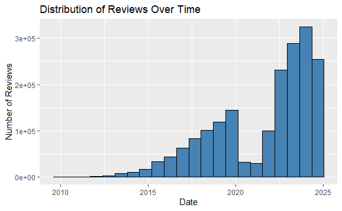

```r
# histogram to understand the distribution of the reviews
library(ggplot2)

ggplot(reviews_data, aes(x = date)) +
  geom_histogram(bins = 22, fill = "steelblue", color = "black") +
  labs(title = "Distribution of Reviews Over Time",
       x = "Date",
       y = "Number of Reviews")
```

# Distribution of reveiws overtime overveiw

The histogram shows that the number of reviews in the earliest years is lower compared to recent years. This trend could be attributed to various factors, including the growth of Airbnb listings over time, increased user adoption, and changes in review culture, all contributing to a rise in review numbers.

## Splitting the Data into Early and Recent Groups

- Splitting the dataset into two groups based on the first and last available years (2009 and 2024).

```r
year_range <- reviews_data |>
  mutate(year = format(date, "%Y")) |>
  pull(year) |>
  unique() |>
  sort()
# Initialising the first and last available years
earliest_year <- min(year_range)
latest_year <- max(year_range)

# dataframes for early and recent reviews
early_reviews <- reviews_data |>
  mutate(year = as.numeric(format(date, "%Y"))) |>
  filter(year == earliest_year)

recent_reviews <- reviews_data |>
  mutate(year = as.numeric(format(date, "%Y"))) |>
  filter(year == latest_year)

nrow(early_reviews)
```

```
[1] 1
```

```r
nrow(recent_reviews)
```

```
[1] 399848
```

```r
head(early_reviews)
```

|  | listing_id | id | date | reviewer_id | reviewer_name | comments | year |
| --- | --- | --- | --- | --- | --- | --- | --- |
| 1 | 15400 | 21032 | 2009-12-21 | 53815 | Hailey | We loved staying at Phillipa's place in Chelsea. The flat was lovely, and the neighborhood was great. Lots of fun shops, and close to two metro stops. We would love to stay there again! | 2009 |

```r
head(recent_reviews)
```

|  | listing_id | id | date | reviewer_id | reviewer_name | comments | year |
| --- | --- | --- | --- | --- | --- | --- | --- |
| 1 | 13913 | 1.148453e+18 | 2024-05-03 | 183479282 | Gemma | Alina is a really lovely host, very friendly and welcoming, and we had some interesting conversations. The flat is in a great location, close to shops and restaurants and easy to walk to the tube. Lov… | 2024 |
| 2 | 13913 | 1.175245e+18 | 2024-06-09 | 35008871 | Zehra | Alina’s place was exactly what I was looking for. I had a perfect sleep each night on a very comfy bed. She is also lovely and friendly | 2024 |
| 3 | 13913 | 1.197766e+18 | 2024-07-10 | 106138105 | Isabell | Alina is a lovely host! Her apartment is bright and clean with high ceilings. The room was great to work from. Location in Finsbury Park is ideal with many shops around and very well connected. Would … | 2024 |
| 4 | 83027 | 1.093380e+18 | 2024-02-17 | 358768588 | Nidal | Berna was excellent host responded to all queries in good time Excellent room very clean I will stay there again if I have to travel to the area | 2024 |
| 5 | 15400 | 1.120257e+18 | 2024-03-25 | 100840491 | Tim | As before, ideal for me and an excellent place to stay. | 2024 |
| 6 | 15400 | 1.144822e+18 | 2024-04-28 | 3321262 | Beth Ann | This was our second stay with Philippa, who once again went out of her way to accommodate our travel plans. Communication was great, and we felt like we were visiting an old friend. The flat was conve… | 2024 |

```r
NA
NA
NA
```

## Text proccessing

- conversion of the comments column to lowercase
- removal of punctuation marks
- splitting the text into individual words (tokens)
- removing stop words that don’t mean anything to the analysis
- removing single characters and html syntax such as (br)

```r
library(dplyr)
library(tidytext)
library(stopwords)
process_text <- function(temp_df) {
  temp_df <- temp_df |>
    mutate(comments_lower = tolower(comments)) |>
    mutate(comments_lower = gsub("[[:punct:]]", " ", comments_lower)) |>
     mutate(comments_lower = gsub("\\b\\w{1}\\b", "", comments_lower)) |>
    mutate(comments_lower = gsub("\\bbr\\b", "",
comments_lower)) |>
    unnest_tokens(word, comments_lower) |>
    anti_join(get_stopwords(language = "en") |>
                rename(word = word), by = "word")

  return(temp_df)
}

early_reviews <- process_text(early_reviews)
recent_reviews <- process_text(recent_reviews)

head(early_reviews)
```

|  | listing_id | id | date | reviewer_id | reviewer_name | comments | year | word |
| --- | --- | --- | --- | --- | --- | --- | --- | --- |
| 1 | 15400 | 21032 | 2009-12-21 | 53815 | Hailey | We loved staying at Phillipa's place in Chelsea. The flat was lovely, and the neighborhood was great. Lots of fun shops, and close to two metro stops. We would love to stay there again! | 2009 | loved |
| 2 | 15400 | 21032 | 2009-12-21 | 53815 | Hailey | We loved staying at Phillipa's place in Chelsea. The flat was lovely, and the neighborhood was great. Lots of fun shops, and close to two metro stops. We would love to stay there again! | 2009 | staying |
| 3 | 15400 | 21032 | 2009-12-21 | 53815 | Hailey | We loved staying at Phillipa's place in Chelsea. The flat was lovely, and the neighborhood was great. Lots of fun shops, and close to two metro stops. We would love to stay there again! | 2009 | phillipa |
| 4 | 15400 | 21032 | 2009-12-21 | 53815 | Hailey | We loved staying at Phillipa's place in Chelsea. The flat was lovely, and the neighborhood was great. Lots of fun shops, and close to two metro stops. We would love to stay there again! | 2009 | place |
| 5 | 15400 | 21032 | 2009-12-21 | 53815 | Hailey | We loved staying at Phillipa's place in Chelsea. The flat was lovely, and the neighborhood was great. Lots of fun shops, and close to two metro stops. We would love to stay there again! | 2009 | chelsea |
| 6 | 15400 | 21032 | 2009-12-21 | 53815 | Hailey | We loved staying at Phillipa's place in Chelsea. The flat was lovely, and the neighborhood was great. Lots of fun shops, and close to two metro stops. We would love to stay there again! | 2009 | flat |

```r
head(recent_reviews)
```

|  | listing_id | id | date | reviewer_id | reviewer_name | comments | year | word |
| --- | --- | --- | --- | --- | --- | --- | --- | --- |
| 1 | 13913 | 1.148453e+18 | 2024-05-03 | 183479282 | Gemma | Alina is a really lovely host, very friendly and welcoming, and we had some interesting conversations. The flat is in a great location, close to shops and restaurants and easy to walk to the tube. Lov… | 2024 | alina |
| 2 | 13913 | 1.148453e+18 | 2024-05-03 | 183479282 | Gemma | Alina is a really lovely host, very friendly and welcoming, and we had some interesting conversations. The flat is in a great location, close to shops and restaurants and easy to walk to the tube. Lov… | 2024 | really |
| 3 | 13913 | 1.148453e+18 | 2024-05-03 | 183479282 | Gemma | Alina is a really lovely host, very friendly and welcoming, and we had some interesting conversations. The flat is in a great location, close to shops and restaurants and easy to walk to the tube. Lov… | 2024 | lovely |
| 4 | 13913 | 1.148453e+18 | 2024-05-03 | 183479282 | Gemma | Alina is a really lovely host, very friendly and welcoming, and we had some interesting conversations. The flat is in a great location, close to shops and restaurants and easy to walk to the tube. Lov… | 2024 | host |
| 5 | 13913 | 1.148453e+18 | 2024-05-03 | 183479282 | Gemma | Alina is a really lovely host, very friendly and welcoming, and we had some interesting conversations. The flat is in a great location, close to shops and restaurants and easy to walk to the tube. Lov… | 2024 | friendly |
| 6 | 13913 | 1.148453e+18 | 2024-05-03 | 183479282 | Gemma | Alina is a really lovely host, very friendly and welcoming, and we had some interesting conversations. The flat is in a great location, close to shops and restaurants and easy to walk to the tube. Lov… | 2024 | welcoming |

```r
NA
NA
```

```r
names(early_reviews)
```

```
[1] "listing_id"    "id"            "date"          "reviewer_id"
[5] "reviewer_name" "comments"      "year"          "word"
```

```r
names(recent_reviews)
```

```
[1] "listing_id"    "id"            "date"          "reviewer_id"
[5] "reviewer_name" "comments"      "year"          "word"
```

```r
dim(early_reviews)
```

```
[1] 18  8
```

```r
dim(recent_reviews)
```

```
[1] 10331343        8
```